# Redes Neuronales en Clasificación

Daniel Stiven Martinez

2023-06-05

## **Arquitectura, aplicación y avances recientes de las redes neuronales**

### **Arquitectura**

La arquitectura de las redes neuronales se compone de una capa de entrada, salida y oculta. Las propias redes neuronales, o redes neuronales artificiales (ANN), son un subconjunto de aprendizaje automático diseñado para imitar la potencia de procesamiento del cerebro humano. Las redes neuronales funcionan pasando datos a través de las capas de una neurona artificial los cuales se transforman internamente mediante una función de activación y como ultimo nos entregan una salida con la cual se toma una decisión.

Gráficamente una red neuronal tiene una estructura como sigue

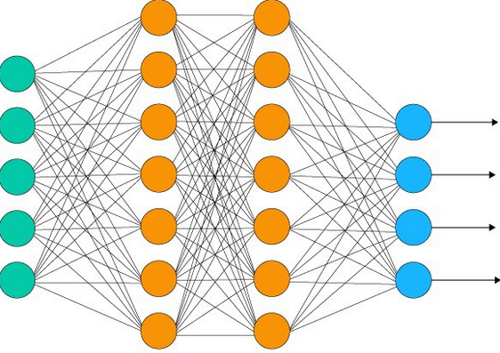

### **Componentes principales de una red neuronal**

Como acabamos de mencionar una red neuronal se componen de una capa entrada , una capa oculta y una de salida, sin embargo internamente hay una una manipulación de los datos mediante una transformación de los mismos.

Para poder describir las componentes de la red neuronal, recordemos su expresión matemática
$$\psi(x)=c_0+\sum_{i=1}^d c_i
\sigma(\psi_i(x)),$$
a partir de esta tenemos que las componentes que conforman una red neuronal son las siguientes

- Entrada : Variable independiente $x$, que a fines prácticos son los datos que se le dan a modelo con fines de aprendizaje y entrenamiento
- Pesos: Corresponde a las constantes $c_i$ las cuales nos ayudan a organizar las variables según su importancia y contribución al modelo que se este estudiando.
- Función de transferencia: Corresponde al procedimiento de sumar todas las entradas transformadas con el fin de combinarlas en una sola variable de salida, específicamente es la suma que aparece en la expresión matemática.
- Función sigmoide ($\sigma$) : En la literatura y contextos de redes neuronales conocida como función de activación, es la que nos ayuda a decidir cuando si o no una neurona debe ser activada, en base a la importancia de las entradas que reciba la neurona. Como recordatorio estas funciones tienen la característica de que $\displaystyle\lim_{x\to \infty} \sigma(x)=1$ y $\displaystyle\lim_{x\to -\infty} \sigma(x)=-1$

### **Tipos de arquitecturas en redes neuronales**

En el contexto de aprendizaje de maquina, las redes neuronales son una forma eficiente para solucionar problemas de la vida diaria, como puede ser en clasificación. Las redes neuronales nos ofrecen respuestas muy bastante precisas en lo que a solución de problemas se refiere, para poder obtener esta precisión se cuenta con distintos tipos de redes que son especificas para problemas concretos, ya que seleccionando la red adecuada podemos incrementar la eficiencia en los resultados que estemos buscando. Entre las redes neuronales mas comunes tenemos

**Redes neuronales estándar**:

Estas son las redes neuronales mas básicas entre ellas tenemos:

- **Perceptron simple**:

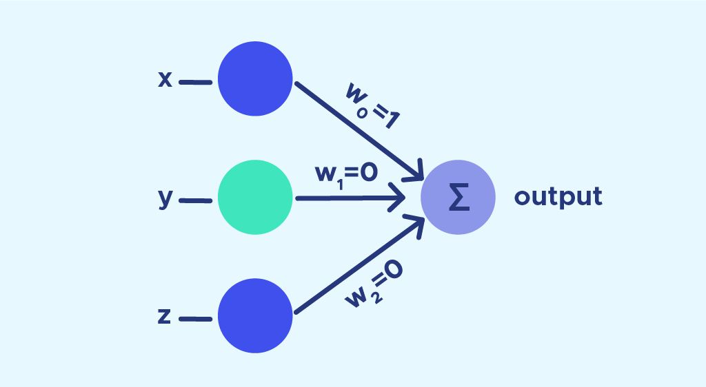

El discriminante lineal o perceptron simple es la red neuronal mas sencilla en donde no tenemos capas ocultas, en el perceptron los datos(input) son transformados de manera lineal mediante una ponderación de manera que obtenemos una respuesta(output), brevemente la idea detrás de esto es que tomamos una decisión
$$\phi(x)=\left\{\begin{array}{cc}
0& \text{ si } \psi(x)\geq 1/2 \\\
1& \text{ e.o.c}
\end{array}\right.$$

basados en la combinación lineal
$$\psi(x)=c_0+\sum_{i=1}^d c_i x_i,$$

donde como mencionamos en un inicio los $c_i's$ son los pesos, $c_0$ es el sesgo y $x=(x_1,\ldots,x_d)$.

- **Redes neuronales prealimentadas (FNN)**:

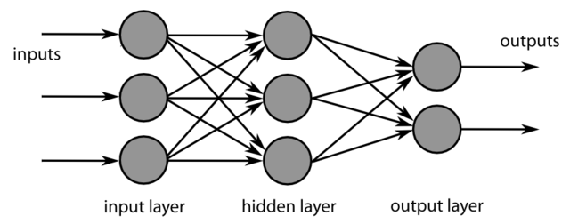

Este tipo de redes es de las primeras en donde consideramos capas ocultas son perceptron con capa oculta, brevemente la idea detrás de este tipo de redes es que ahora la decisión que se toma depende de
$$\psi(x)=c_0+\sum_{i=1}^d c_i
\sigma(\psi_i(x))$$

donde los $c_i$ son igual a como se mencionaron antes y cada $\psi_i(x)$ es de la forma

$$\psi_i(x)=b_i+\sum_{j=1}^d a_{ij}
x_j$$

En este caso de perceptron con una capa oculta decimos que hay $k$ neuronas ocultas y la salida de la $i$-ésima neurona oculta es $u_i=\sigma(\psi_i(x))$. De modo que podemos reescribir a $\psi(x)$ como
$$\psi(x)=c_0+\sum_{i=1}^k c_i
u_i$$

De igual forma a como consideramos una capa oculta las redes neuronales prealimentadas, se puede considerar mas capas ocultadas en la red neuronal, veamos el caso con dos capas ocultas y casos generales con mas capas siguen la misma idea.

Para un perceptron con dos capas ocultas tenemos

$$\psi_i(x)=c_0+\sum_{j=1}^l c_i
z_i,$$
donde
$$z_i=\sigma\left(d_{i0}+\sum_{j=1}^k d_{ij}
u_j\right),\quad 1\leq i\leq l$$
y
$$u_j=\sigma\left(b_j+\sum_{j=1}^k a_{ij}
x_i\right),\quad 1\leq j\leq k$$
donde los $d_{ij},b_j$ y $a_{ij}$ son constantes. En este caso concreto contamos con $k$ neuronas ocultas en la primera capa y $l$ neuronas ocultas para la segunda capa.

**Redes neuronales recurrentes (RNN)**

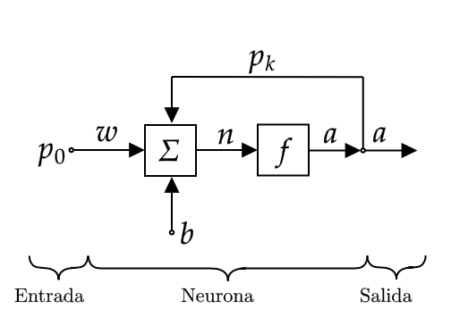

Las redes neuronales recurrentes (RNN) son un tipo de redes muy útiles, las cuales recuerdan las predicciones aprendidas previamente para ayudar a hacer predicciones futuras con precisión (tienen memoria) el esquema de este tipo de redes se puede observar en la imagen anterior. Este tipo de redes son muy usados en modelos de Deep learning de problemas ordinales o temporales, como pueden ser la traducción idiomas o el reconocimiento de voz(asistente como Alexa)

La como acabamos de mencionar las RNN recuerdan las predicciones que han hecho para mejor la precisión un ejemplo de aplicación de este tipo de redes es el de predicción de texto, como por ejemplo cuando escribes una oración para enviárselo a un amigo, el celular aprende de las palabras que has usado y en el orden en que lo has hecho para hacerte sugerencias y escribir mas rápido, como puede ser en la oración **¿Como te ha ido?**, si empiezas con la palabra **como**, tu teclado te ira sugiriendo **te**, **ha** y **ido**, en incluso como va aprendiendo puede predecir que la palabra siguiente sera **hoy**.

- **Redes con memoria a corto y largo plazo (LSTM)**

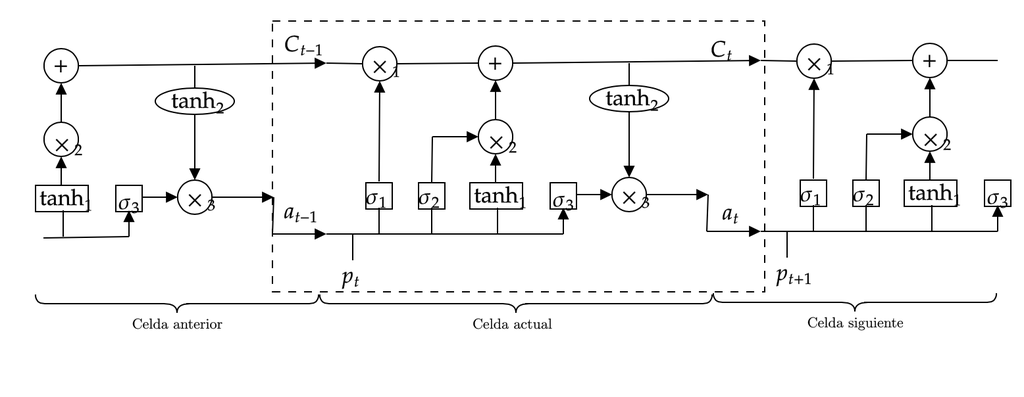

Las redes neuronales con memoria a corto y largo plazo (LSTM por sus siglas en ingles) son un tipo especial de redes recurrentes. La característica principal de las redes recurrentes es que la información puede persistir introduciendo ciclos en la red, por lo que, básicamente, pueden “recordar” estados previos y utilizar esta información para predecir la salida siguiente. Esta característica las hace muy adecuadas para manejar datos que provienen de series de tiempo. Mientras las redes recurrentes estándar pueden modelar dependencias a corto plazo (es decir, relaciones cercanas en la serie cronológica), las LSTM pueden aprender dependencias largas, por lo que se podría decir que tienen una memoria a más largo plazo

**Redes neuronales convolucionales (CNN)**

Mientras las RNN se usan comúnmente para el procesamiento del lenguaje natural y el reconocimiento de voz, las CNN se utilizan con mayor frecuencia para tareas de clasificación como lo son el análisis de imágenes, el procesamiento del lenguaje natural y otros problemas complejos de clasificación y visión por computadora. Antes de las CNN, se utilizaban métodos manuales y poco eficientes para identificar los objetos que aparecían en una imagen, lo cual a larga conllevaba mayor tiempo y gasto comunicacional. Sin embargo, las redes neuronales convolucionales ahora brindan un enfoque más escalable para las tareas de clasificación de imágenes y reconocimiento de objetos, aprovechando los principios del álgebra lineal, específicamente la multiplicación de matrices, para identificar patrones dentro de una imagen.

## **Implementación y ejemplos**